# DREAM Mixture ML Intro

Joel Mainland

2024-05-31

# Look at the data

```r
#This is generated from Preprocessing.R
mixturesWithFeatures <- read.csv("data/processed/MixturesWithFeatures.csv")

# You can load from Dropbox if you are having issues loading from the workspace:
# mixturesWithFeatures <- read.csv("https://www.dropbox.com/scl/fi/f75j07xedtsv3774con0k/MixturesWithFeatures.csv?rlkey=lyfw541vdb6byhpj1341etvnu&dl=1", row.names=NULL)

glimpse(mixturesWithFeatures)
```

```
## Rows: 548
## Columns: 11
## $ dataset             <chr> "Snitz 1", "Snitz 1", "Snitz 1", "Snitz 1", "Snitz…
## $ mixture_1           <int> 1, 1, 1, 1, 1, 1, 3, 3, 3, 3, 8, 8, 8, 8, 8, 8, 9,…
## $ mixture_2           <int> 2, 3, 4, 5, 6, 7, 38, 39, 40, 41, 2, 3, 4, 5, 6, 7…
## $ experimental_values <dbl> 0.6041667, 0.6510417, 0.5260417, 0.5052083, 0.4114…
## $ a                   <chr> "6501;264;2879;7685;7731;326;7888;61138;8030;1183"…
## $ b                   <chr> "240;93009;323;8148;7762;3314;460;6184;798;6054", …
## $ num_compound_a      <int> 10, 10, 10, 10, 10, 10, 1, 1, 1, 1, 1, 1, 1, 1, 1,…
## $ num_compound_b      <int> 10, 1, 20, 30, 40, 4, 15, 20, 30, 43, 10, 1, 20, 3…
## $ diff_mixture_size   <int> 0, 9, 10, 20, 30, 6, 14, 19, 29, 42, 9, 0, 19, 29,…
## $ overlap_percent     <dbl> 0, 0, 0, 0, 0, 0, 0, 0, 0, 0, 0, 0, 0, 0, 0, 0, 0,…
## $ angle_dist          <dbl> 0.03592652, 0.04259934, 0.01889634, 0.02622709, 0.…
```

# Visualize the data

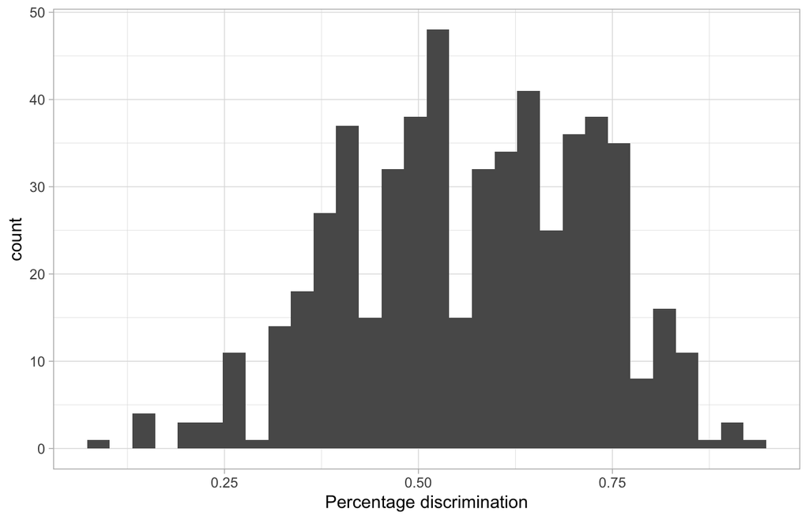

```r
mixturesWithFeatures %>%
  ggplot(aes(x = experimental_values)) +
  geom_histogram() +
  labs(x="Percentage discrimination")
```

High values on the x-axis correspond to mixture pairs that are easy to discriminate. There are a handful of mixture pairs that are very similar to each other.

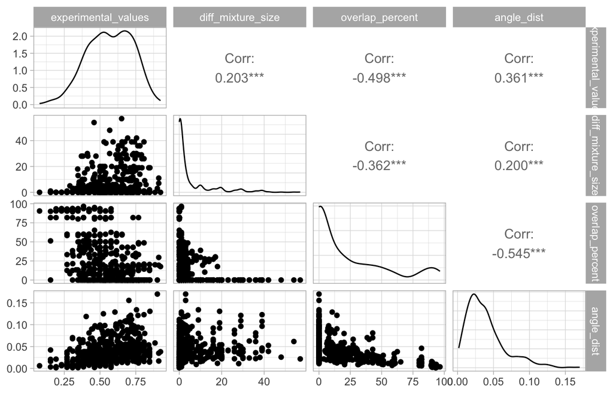

```r
ggpairs(mixturesWithFeatures,columns=c(4,9,10,11))
```

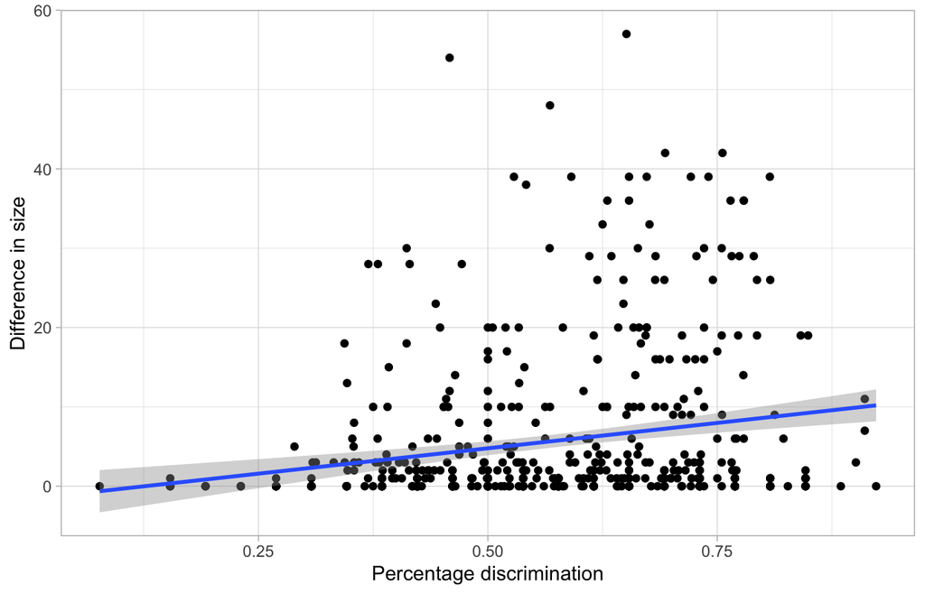

```r
#Discrimination vs. Difference in size
mixturesWithFeatures %>%
  ggplot(aes(y = diff_mixture_size, x = experimental_values)) +
  geom_point() +
  geom_smooth(method = "lm")+
  labs(x="Percentage discrimination",y="Difference in size")
```

In general, mixture pairs that differ in the number of components are easier to discriminate. This effect appears to be driven by the very similar pairs that are all also very similar in size.

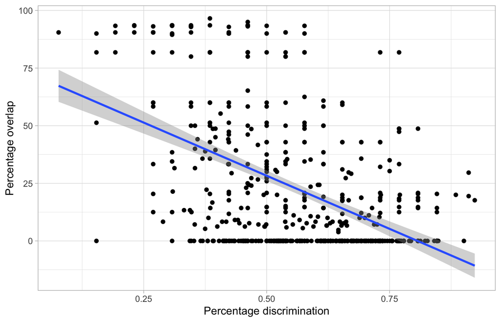

```r
#Discrimination vs. Percentage overlap
mixturesWithFeatures %>%
  ggplot(aes(y = overlap_percent, x = experimental_values)) +
  geom_point() +
  geom_smooth(method = "lm")+
  labs(x="Percentage discrimination",y="Percentage overlap")
```

In general, pairs with low overlap in components are easy to discriminate.

We can see one mixture pair that has no overlap in molecules, but could only be discriminated on ~15% of trials. This is a possible metameric pair.

Snitz et al., 2013 has a published algorithm for predicting how similar two mixtures are, and their data are in this training set. Let’s see how well that model does on all of the data.

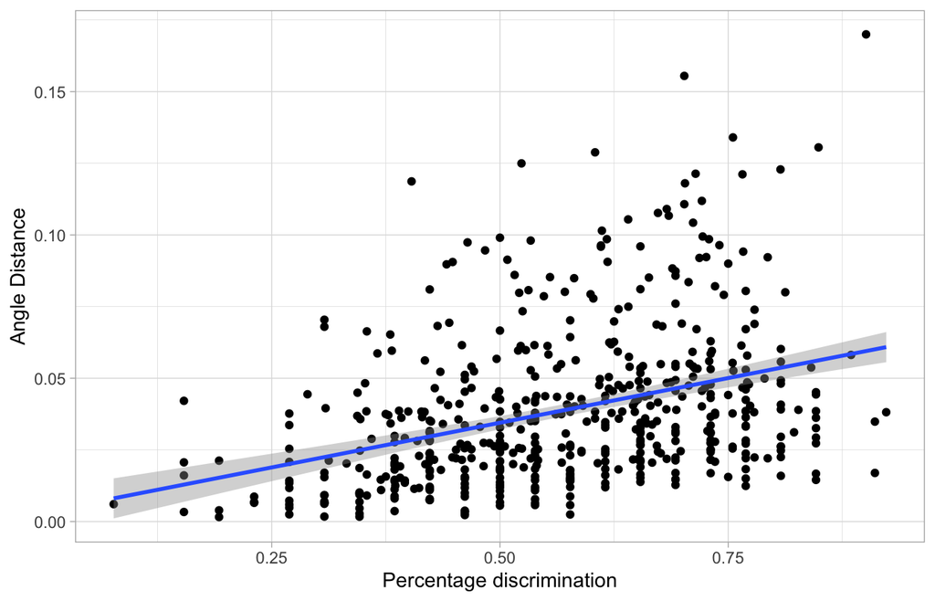

```r
#Discrimination vs. Angle Distance
mixturesWithFeatures %>%
  ggplot(aes(y = angle_dist, x = experimental_values)) +
  geom_point() +
  geom_smooth(method = "lm")+
  labs(x="Percentage discrimination",y="Angle Distance")
```

```r
fit1 <- lm(angle_dist ~ experimental_values, data = mixturesWithFeatures)

print(paste0("Adj R2 = ",signif(summary(fit1)$adj.r.squared, 5)))
```

```
## [1] "Adj R2 = 0.12849"
```

```r
print(paste0(" P =",signif(summary(fit1)$coef[2,4], 5)))
```

```
## [1] " P =2.805e-18"
```

# Basic machine learning

## Split the data

```r
mixtures.clean <- mixturesWithFeatures %>%
  #mutate(ID = row_number()) %>%
  select(experimental_values,diff_mixture_size,overlap_percent,angle_dist)

#divide into training and test sets
set.seed(42)
# Create a data partition: 80% for training, 20% for testing
trainIndex <- createDataPartition(mixtures.clean$experimental_values, p = 0.8, list = FALSE)

# Create the training and testing sets
train_set <- mixtures.clean[trainIndex, ]
test_set <- mixtures.clean[-trainIndex, ]
```

## Linear Model

```r
#fit a linear model
model_linear <- lm(experimental_values ~ diff_mixture_size + overlap_percent + angle_dist, data = train_set)

# View the summary of the model
summary(model_linear)
```

```
##
## Call:
## lm(formula = experimental_values ~ diff_mixture_size + overlap_percent +
##     angle_dist, data = train_set)
##
## Residuals:
##      Min       1Q   Median       3Q      Max
## -0.46122 -0.09269  0.00589  0.09136  0.35990
##
## Coefficients:
##                     Estimate Std. Error t value Pr(>|t|)
## (Intercept)        0.5705318  0.0178630  31.939  < 2e-16 ***
## diff_mixture_size  0.0003972  0.0007227   0.550 0.582810
## overlap_percent   -0.0020038  0.0002810  -7.131 4.17e-12 ***
## angle_dist         1.0574525  0.3005934   3.518 0.000481 ***
## ---
## Signif. codes:  0 '***' 0.001 '**' 0.01 '*' 0.05 '.' 0.1 ' ' 1
##
## Residual standard error: 0.1349 on 437 degrees of freedom
## Multiple R-squared:  0.2558, Adjusted R-squared:  0.2507
## F-statistic: 50.06 on 3 and 437 DF,  p-value: < 2.2e-16
```

## Make predictions

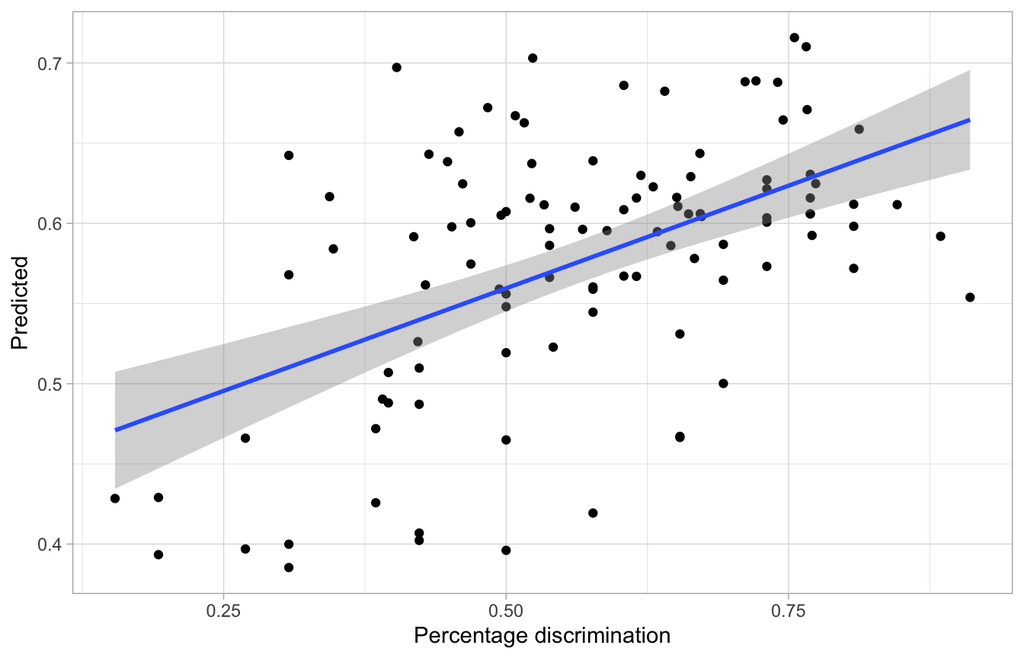

```r
test_set$predicted <- predict(model_linear, newdata = test_set)

test_set %>%
  ggplot(aes(x=experimental_values,y=predicted))+
  geom_point() +
  geom_smooth(method = "lm")+
  labs(x="Percentage discrimination",y="Predicted")
```

## Characterize Performance

```r
# Calculate Mean Squared Error
mse <- mean((test_set$experimental_values - test_set$predicted)^2)
print(paste("Mean Squared Error:", mse))
```

```
## [1] "Mean Squared Error: 0.0191725597427043"
```

```r
# Calculate R-squared on the test set
ss_total <- sum((test_set$experimental_values - mean(test_set$experimental_values))^2)
ss_residual <- sum((test_set$experimental_values - test_set$predicted)^2)
r_squared <- 1 - (ss_residual / ss_total)
print(paste("R-squared on test set:", r_squared))
```

```
## [1] "R-squared on test set: 0.263343178822379"
```

# Random Forest

```r
#Build a random forest
r = randomForest(experimental_values ~., data=train_set, importance=TRUE, do.trace=100)
```

```
##      |      Out-of-bag   |
## Tree |      MSE  %Var(y) |
##  100 |  0.01827    75.39 |
##  200 |  0.01816    74.93 |
##  300 |  0.01798    74.20 |
##  400 |  0.01797    74.16 |
##  500 |  0.01798    74.18 |
```

```r
print(r)
```

```
##
## Call:
##  randomForest(formula = experimental_values ~ ., data = train_set,      importance = TRUE, do.trace = 100)
##                Type of random forest: regression
##                      Number of trees: 500
## No. of variables tried at each split: 1
##
##           Mean of squared residuals: 0.01797761
##                     % Var explained: 25.82
```

Tree shows the number of trees at each stage of evaluation. MSE is the mean-squared error of the predictions for out-of-bag samples. Percentage of variance explained–higher is better.

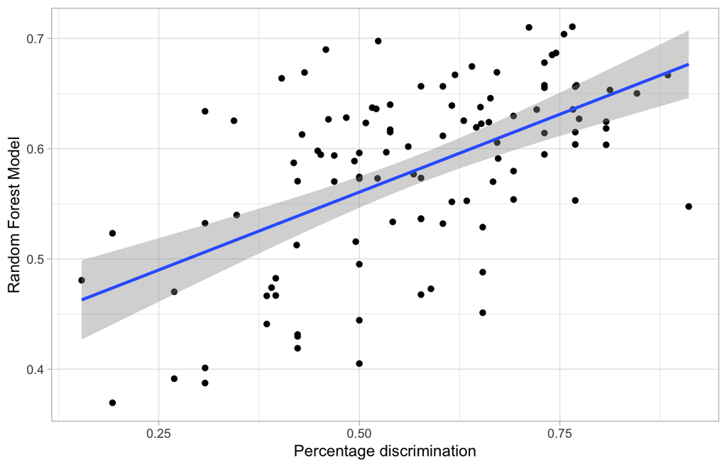

```r
#Now try it on the test set
mixture.predict = predict(r, test_set)
mixture.results <- cbind(test_set,Predicted=mixture.predict)

mixture.results %>%
  ggplot(aes(y = mixture.predict, x = experimental_values)) +
  geom_point() +
  geom_smooth(method = "lm")+
  labs(x="Percentage discrimination",y="Random Forest Model")
```

```r
fit2 <- lm(mixture.predict ~ experimental_values, data = mixture.results)

print(paste0("Adj R2 = ",signif(summary(fit2)$adj.r.squared, 5)))
```

```
## [1] "Adj R2 = 0.3068"
```

```r
print(paste0(" P =",signif(summary(fit2)$coef[2,4], 5)))
```

```
## [1] " P =3.6527e-10"
```

```r
importance(r)
```

```
##                    %IncMSE IncNodePurity
## diff_mixture_size 13.42197      1.115440
## overlap_percent   35.78884      2.565605
## angle_dist        30.76258      3.001925
```

%IncMSE: This column shows the percentage increase in the mean squared error (MSE) when a given variable is randomly permuted (its values are shuffled). A higher value indicates that the variable is more important for predicting the target variable because permuting it leads to a larger increase in the MSE.

IncNodePurity: This column shows the total decrease in node impurity (measured by residual sum of squares for regression) that results from splits on this variable, averaged over all trees. A higher value indicates that the variable contributes more to reducing the impurity of nodes in the trees, thus making it a more important predictor.

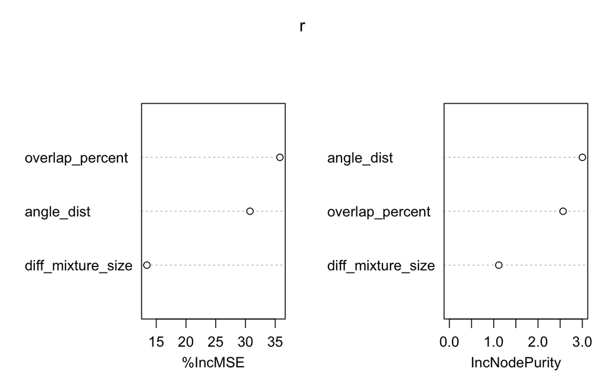

```r
varImpPlot(r)
```

Difference in mixture size is the least important variable. The two metrics disagree on which of the other two predictors are more important

# Simple caret structure

```r
#define training control
fitControl <- trainControl(method = "repeatedcv",number = 5,repeats = 2) #5 fold cv, repeat 2 times

rfFit<-train(experimental_values ~ diff_mixture_size + overlap_percent + angle_dist, data = train_set,
             method = "rf",
             trControl = fitControl,
             metric="RMSE")
#Look at performance in cross-validation
print(rfFit)
```

```
## Random Forest
##
## 441 samples
##   3 predictor
##
## No pre-processing
## Resampling: Cross-Validated (5 fold, repeated 2 times)
## Summary of sample sizes: 352, 354, 352, 352, 354, 353, ...
## Resampling results across tuning parameters:
##
##   mtry  RMSE       Rsquared   MAE
##   2     0.1396963  0.2207158  0.1138688
##   3     0.1416608  0.2078529  0.1150832
##
## RMSE was used to select the optimal model using the smallest value.
## The final value used for the model was mtry = 2.
```

# Ideas for contributing

## Feature engineering

Think of a new feature that might help us predict mixture discriminability and add it as a column to mixturesWithFeatures

## Feature selection

Although machine learning models are designed to figure out which features best predict the outcome variable, pruning features that are irrelevant will improve performance.

## Model comparisons

In the train block, you can change ‘method = “rf”’ to use a huge number of different models. Here is a list of possible models: https://topepo.github.io/caret/available-models.html

## Additional data

One of the most straightforward ways to improve a model is to train it on a larger dataset. Is there any dataset (for example at pyrfume.org) that can be used to train your model?